# Fundamental of `NumPy`

## 3. Basic Indexing and Slicing

#### 3.1 One-dimensional arrays are simple; on the surface they act similarly to Python lists

```python
arr = np.arange(10)
arr
```

```
array([0, 1, 2, 3, 4, 5, 6, 7, 8, 9])
```

```python
arr[5]
```

```
5
```

```python
arr[5:8]
```

```
array([5, 6, 7])
```

```python
arr[5:9] = 11
arr
```

```
array([ 0,  1,  2,  3,  4, 11, 11, 11, 11,  9])
```

if you assign a scalar value to a slice, as in arr[5:9] = 11, the value is propagated (or broadcasted henceforth) to the entire selection.

An important first distinction from Python’s built-in lists is that `array slices are views on the original array.` This means that `the data is not copied,` and any modifications to the view will be reflected in the source array.

```python
arr_slice = arr[5:9]
arr_slice
```

```
array([11, 11, 11, 11])
```

```python
arr_slice[1] = 123456
arr
```

```
array([     0,      1,      2,      3,      4,     11, 123456,     11,
           11,      9])
```

```python
arr_slice[:] = 64
arr
```

```
array([ 0,  1,  2,  3,  4, 64, 64, 64, 64,  9])
```

**As NumPy has been designed to be able to work with very large arrays**, you could imagine **performance and memory problems** if NumPy insisted on always copying data

#### 3.2 With higher dimensional arrays, you have many more options.

In a two-dimensional array, the elements at each index are no longer scalars but rather one-dimensional arrays:

```python
arr2d = np.array([[1,2,3],[4,5,6],[7,8,9]])
arr2d[2]
```

```
array([7, 8, 9])
```

```python
arr2d[0][2]
```

```
3
```

```python
arr2d[0,2] # same to above expression
```

```
3
```

See Figure 4-1 for an illustration of indexing on a two-dimensional array. I find it helpful to think of **axis 0 as the “rows”** of the array and **axis 1 as the “columns.**

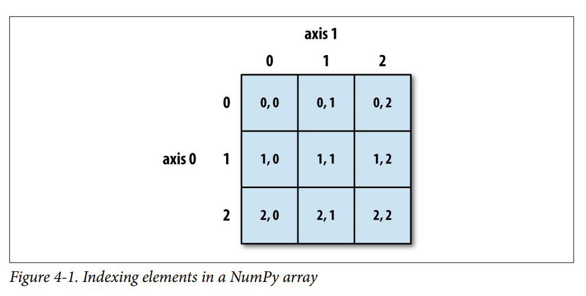

```python
arr3d = np.array([[[1, 2, 3], [4, 5, 6]], [[7, 8, 9], [10, 11, 12]]])
arr3d
```

```
array([[[ 1,  2,  3],
        [ 4,  5,  6]],

       [[ 7,  8,  9],
        [10, 11, 12]]])
```

arr3d[0] is a 2 × 3 array:

```python
arr3d[0]
```

```
array([[1, 2, 3],
       [4, 5, 6]])
```

Both scalar values and arrays can be assigned to arr3d[0]:

```python
old_values = arr3d[0].copy()
arr3d[0] = 42
arr3d
```

```
array([[[42, 42, 42],
        [42, 42, 42]],

       [[ 7,  8,  9],
        [10, 11, 12]]])
```

```python
arr3d[0] = old_values
arr3d
```

```
array([[[ 1,  2,  3],
        [ 4,  5,  6]],

       [[ 7,  8,  9],
        [10, 11, 12]]])
```

Note that in all of these cases where subsections of the array have been selected, **the returned arrays are views.** unless you use `copy()`

#### Indexing with slices

Like one-dimensional objects such as Python lists, ndarrays can be sliced with the familiar syntax:

```python
arr
```

```
array([ 0,  1,  2,  3,  4, 64, 64, 64, 64,  9])
```

```python
arr[1:6]
```

```
array([ 1,  2,  3,  4, 64])
```

Consider the two-dimensional array from before, arr2d. Slicing this array is a bit different:

```python
arr2d
```

```
array([[1, 2, 3],
       [4, 5, 6],
       [7, 8, 9]])
```

As you can see, it has sliced along axis 0, the first axis. A slice, therefore, selects a range of elements along an axis. It can be helpful to read **the expression arr2d[:2] as “select the first two rows of arr2d.**

```python
arr2d[:2]
```

```
array([[1, 2, 3],
       [4, 5, 6]])
```

#### For example, I can select the second row but only the first two columns like so:

```python
arr2d[1, :2]
```

```
array([4, 5])
```

#### Similarly, I can select the third column but only the first two rows like so:

```python
arr2d[:2, 2]
```

```
array([3, 6])
```

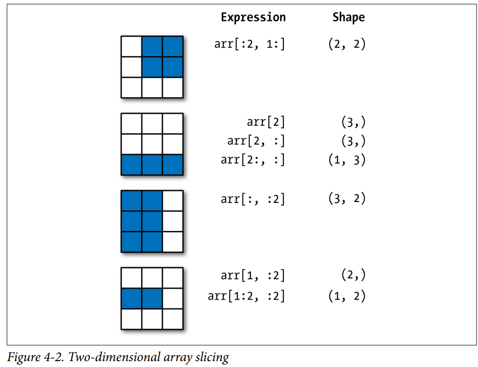

## 4. Boolean Indexing

I’m going to use here the randn function in numpy.random to generate some random normally distributed data:

```python
names = np.array(['Bob', 'Joe', 'Will', 'Bob', 'Will', 'Joe', 'Joe'])
names
```

```
array(['Bob', 'Joe', 'Will', 'Bob', 'Will', 'Joe', 'Joe'], dtype='<U4')
```

```python
data = np.random.randn(7, 4)
data
```

```
array([[-0.98375774,  0.44187629, -1.1100036 , -0.88726627],
       [ 1.13855078,  0.93251369, -0.80758053, -0.94110179],
       [ 0.00395748,  0.38095033,  1.87555966, -1.4672527 ],
       [ 1.35124282, -0.35721095,  0.19962823,  0.32729157],
       [ 0.5117263 ,  1.7416916 , -2.23335676,  0.48517241],
       [-0.22611517, -0.17956134,  0.32540227,  0.90222089],
       [ 0.67406686,  0.58338844, -0.90754481,  0.47108654]])
```

```python
names == 'Bob'
```

```
array([ True, False, False,  True, False, False, False])
```

#### This boolean array can be passed when indexing the array

```python
data[names == 'Bob']
```

```
array([[-0.98375774,  0.44187629, -1.1100036 , -0.88726627],
       [ 1.35124282, -0.35721095,  0.19962823,  0.32729157]])
```

#### In these examples, I select from the rows where names == 'Bob' and index the columns, too:

```python
 data[names == 'Bob', 2:]
```

```
array([[-1.1100036 , -0.88726627],
       [ 0.19962823,  0.32729157]])
```

#### To select everything but 'Bob', you can either use `!=` or negate the condition using `~`:

```python
data[names != 'Bob']
```

```
array([[ 1.13855078,  0.93251369, -0.80758053, -0.94110179],
       [ 0.00395748,  0.38095033,  1.87555966, -1.4672527 ],
       [ 0.5117263 ,  1.7416916 , -2.23335676,  0.48517241],
       [-0.22611517, -0.17956134,  0.32540227,  0.90222089],
       [ 0.67406686,  0.58338844, -0.90754481,  0.47108654]])
```

```python
data[~(names == 'Bob')]
```

```
array([[ 1.13855078,  0.93251369, -0.80758053, -0.94110179],
       [ 0.00395748,  0.38095033,  1.87555966, -1.4672527 ],
       [ 0.5117263 ,  1.7416916 , -2.23335676,  0.48517241],
       [-0.22611517, -0.17956134,  0.32540227,  0.90222089],
       [ 0.67406686,  0.58338844, -0.90754481,  0.47108654]])
```

The `~` operator can be useful when you want to **invert** a general condition:

```python
cond = names == 'Bob'
data[~cond]
```

```
array([[ 1.13855078,  0.93251369, -0.80758053, -0.94110179],
       [ 0.00395748,  0.38095033,  1.87555966, -1.4672527 ],
       [ 0.5117263 ,  1.7416916 , -2.23335676,  0.48517241],
       [-0.22611517, -0.17956134,  0.32540227,  0.90222089],
       [ 0.67406686,  0.58338844, -0.90754481,  0.47108654]])
```

Selecting two of the three names to combine multiple boolean conditions, **use boolean arithmetic operators like & (and) and | (or):**

```python
mask = (names == 'Bob') | (names == 'Will')
mask
```

```
array([ True, False,  True,  True,  True, False, False])
```

Selecting data from an array **by boolean indexing always creates a copy of the data,** even if the returned array is unchanged.

#### To set all of the negative values in data to 0 we need only do:

```python
data[data < 0] = 0
data
```

```
array([[0.        , 0.44187629, 0.        , 0.        ],
       [1.13855078, 0.93251369, 0.        , 0.        ],
       [0.00395748, 0.38095033, 1.87555966, 0.        ],
       [1.35124282, 0.        , 0.19962823, 0.32729157],
       [0.5117263 , 1.7416916 , 0.        , 0.48517241],
       [0.        , 0.        , 0.32540227, 0.90222089],
       [0.67406686, 0.58338844, 0.        , 0.47108654]])
```

#### Setting whole rows or columns using a one-dimensional boolean array is also easy

```python
data[names != 'Joe'] = 7
data
```

```
array([[7.        , 7.        , 7.        , 7.        ],
       [1.13855078, 0.93251369, 0.        , 0.        ],
       [7.        , 7.        , 7.        , 7.        ],
       [7.        , 7.        , 7.        , 7.        ],
       [7.        , 7.        , 7.        , 7.        ],
       [0.        , 0.        , 0.32540227, 0.90222089],
       [0.67406686, 0.58338844, 0.        , 0.47108654]])
```

## 5. Fancy Indexing

`Fancy indexing` is a term adopted by NumPy to describe **indexing using integer arrays**

```python
arr = np.empty((8,4))
for i in range(8):
    arr[i] = i
arr
```

```
array([[0., 0., 0., 0.],
       [1., 1., 1., 1.],
       [2., 2., 2., 2.],
       [3., 3., 3., 3.],
       [4., 4., 4., 4.],
       [5., 5., 5., 5.],
       [6., 6., 6., 6.],
       [7., 7., 7., 7.]])
```

To select out a subset of the rows in a particular order, you can simply pass a `list` or `ndarray` of integers **specifying the desired order:**

```python
arr[[4,2,0,7]]
```

```
array([[4., 4., 4., 4.],
       [2., 2., 2., 2.],
       [0., 0., 0., 0.],
       [7., 7., 7., 7.]])
```

```python
arr[[-3,-5,-7]]
```

```
array([[5., 5., 5., 5.],
       [3., 3., 3., 3.],
       [1., 1., 1., 1.]])
```

Passing **multiple index arrays does something slightly different**; it selects a **onedimensional array** of elements corresponding to each tuple of indices:

```python
arr = np.arange(32).reshape((8, 4))
arr
```

```
array([[ 0,  1,  2,  3],
       [ 4,  5,  6,  7],
       [ 8,  9, 10, 11],
       [12, 13, 14, 15],
       [16, 17, 18, 19],
       [20, 21, 22, 23],
       [24, 25, 26, 27],
       [28, 29, 30, 31]])
```

```python
arr[[1, 5, 7, 2], [0, 3, 1, 2]]
```

```
array([ 4, 23, 29, 10])
```

## Transposing Arrays and Swapping Axes

Transposing is a special form of reshaping that similarly **returns a view** on the underlying data without copying anything. Arrays have the `transpose` method and also the special `T` attribute:

```python
arr = np.arange(15).reshape((3, 5))
arr
```

```
array([[ 0,  1,  2,  3,  4],
       [ 5,  6,  7,  8,  9],
       [10, 11, 12, 13, 14]])
```

```python
arr.T
```

```
array([[ 0,  5, 10],
       [ 1,  6, 11],
       [ 2,  7, 12],
       [ 3,  8, 13],
       [ 4,  9, 14]])
```

When doing matrix computations, you may do this very often—for example, when computing the **inner matrix product** using `np.dot`

```python
arr = np.random.randn(6, 3)
arr
```

```
array([[ 0.33076394, -0.33278564,  0.83471711],
       [ 0.44856004,  1.30520533, -0.77457681],
       [ 2.29713505,  0.14912662,  0.91958075],
       [ 1.91710434, -0.72974655, -1.06487843],
       [ 0.12304035, -0.47433004, -0.25653274],
       [ 1.42740697,  0.07532958,  0.82689851]])
```

```python
np.dot(arr.T,arr)
```

```
array([[11.315359  , -0.53188259,  1.14832504],
       [-0.53188259,  2.59973955, -0.19056722],
       [ 1.14832504, -0.19056722,  4.02588692]])
```

For higher dimensional arrays, transpose will accept a tuple of axis numbers to permute the axes (for extra mind bending):

```python
arr = np.arange(16).reshape((2, 2, 4))
arr
```

```
array([[[ 0,  1,  2,  3],
        [ 4,  5,  6,  7]],

       [[ 8,  9, 10, 11],
        [12, 13, 14, 15]]])
```

```python
arr.transpose((1, 0, 2))
```

```
array([[[ 0,  1,  2,  3],
        [ 8,  9, 10, 11]],

       [[ 4,  5,  6,  7],
        [12, 13, 14, 15]]])
```

Simple transposing with `.T` is a special case of `swapping axes`. ndarray has the method `swapaxes`, which **takes a pair of axis numbers and switches the indicated axes to rearrange the data:**

```python
arr
```

```
array([[[ 0,  1,  2,  3],
        [ 4,  5,  6,  7]],

       [[ 8,  9, 10, 11],
        [12, 13, 14, 15]]])
```

```python
arr.swapaxes(0, 1)
```

```
array([[[ 0,  1,  2,  3],
        [ 8,  9, 10, 11]],

       [[ 4,  5,  6,  7],
        [12, 13, 14, 15]]])
```

#### Notice! `swapaxes` similarly returns a view on the data without making a copy.